# Output_SPSS_bootmean

[output not shown]

- Log
  - Log
- Graph
  - Histogram of i1
- Log
  - Log
- Frequencies
  - Statistics
  - Histogram
- Log
  - Log
- Bootstrap
  - Bootstrap Specifications
- Log
  - Log
- Descriptives
  - Descriptive Statistics
- Delete

Log  
Log - Log - September 24, 2017

* Encoding: UTF-8.  
* working with helpmkh.sav SPSS dataset.  
* draw a histogram with normal curve.  
GRAPH  
/HISTOGRAM(NORMAL)=i1.

Graph  
Graph - Histogram of i1 - September 24, 2017

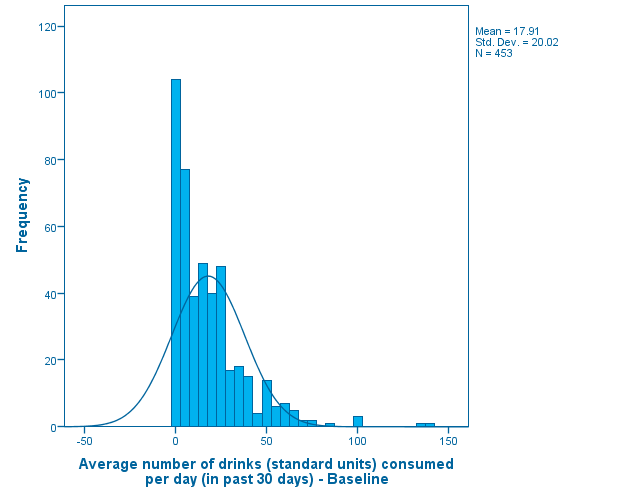

Log  
Log - Log - September 24, 2017

* can also get the stats and the histogram with curve  
* using the FREQUENCIES procedure.  
FREQUENCIES VARIABLES=i1  
/FORMAT=NOTABLE  
/NTILES=4  
/STATISTICS=STDDEV MINIMUM MAXIMUM MEAN  
/HISTOGRAM NORMAL  
/ORDER=ANALYSIS.

Frequencies  
Frequencies - Statistics - September 24, 2017

StatisticsStatistics, table, i1 Average number of drinks (standard units) consumed per day (in past 30 days) - Baseline, 1 layers, 0 levels of column headers and 2 levels of row headers, table with 3 columns and 11 rows

| i1 Average number of drinks (standard units) consumed per day (in past 30 days) - Baseline i1 Average number of drinks (standard units) consumed per day (in past 30 days) - Baseline |  |  |
| --- | --- | --- |
| N | Valid | 453 |
|  | Missing | 0 |
| Mean |  | 17.91 |
| Std. Deviation |  | 20.020 |
| Minimum |  | 0 |
| Maximum |  | 142 |
| Percentiles | 25 | 3.00 |
|  | 50 | 13.00 |
|  | 75 | 26.00 |

Frequencies  
Frequencies - Histogram - September 24, 2017

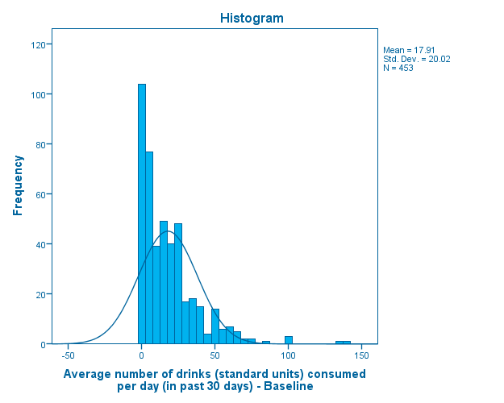

Log  
Log - Log - September 24, 2017

* get bootstrapped estimate BCA type  
* for the mean.  
BOOTSTRAP  
/SAMPLING METHOD=SIMPLE  
/VARIABLES INPUT=i1  
/CRITERIA CILEVEL=95 CITYPE=BCA NSAMPLES=1000  
/MISSING USERMISSING=EXCLUDE.

Bootstrap  
Bootstrap - Bootstrap Specifications - September 24, 2017

Bootstrap SpecificationsBootstrap Specifications, table, 0 levels of column headers and 1 levels of row headers, table with 2 columns and 5 rows

| Sampling Method | Simple |
| --- | --- |
| Number of Samples | 1000 |
| Confidence Interval Level | 95.0% |
| Confidence Interval Type | Bias-corrected and accelerated (BCa) |

Log  
Log - Log - September 24, 2017

DESCRIPTIVES VARIABLES=i1  
/STATISTICS=MEAN STDDEV MIN MAX.

Descriptives  
Descriptives - Descriptive Statistics - September 24, 2017

Descriptive StatisticsDescriptive Statistics, table, 3 levels of column headers and 2 levels of row headers, table with 7 columns and 11 rows

|  |  | Statistic | Bootstrap<sup>a</sup> |  |  |  |
| --- | --- | --- | --- | --- | --- | --- |
|  |  |  | Bias | Std. Error | BCa 95% Confidence Interval |  |
|  |  |  |  |  | Lower | Upper |
| i1 Average number of drinks (standard units) consumed per day (in past 30 days) - Baseline | N | 453 | 0 | 0 | . | . |
|  | Minimum | 0 |  |  |  |  |
|  | Maximum | 142 |  |  |  |  |
|  | Mean | 17.91 | .01 | .92 | 16.15 | 19.83 |
|  | Std. Deviation | 20.020 | -.019 | 1.338 | 17.668 | 22.536 |
| Valid N (listwise) | N | 453 | 0 | 0 | . | . |

a. Unless otherwise noted, bootstrap results are based on 1000 bootstrap samples

[output not shown]

[output not shown]

[output not shown]

[output not shown]

[output not shown]

[output not shown]